# task5

```python
import re
import time

import gensim.downloader as api
import matplotlib.pyplot as plt
import nltk
import numpy as np
import pandas as pd
import seaborn as sns
import torch
from nltk.corpus import stopwords
from nltk.stem import PorterStemmer
from sklearn.datasets import fetch_20newsgroups
from sklearn.ensemble import RandomForestClassifier
from sklearn.feature_extraction.text import CountVectorizer, TfidfVectorizer
from sklearn.linear_model import LogisticRegression
from sklearn.metrics import (
    accuracy_score,
    classification_report,
    confusion_matrix,
    f1_score,
)
from sklearn.model_selection import GridSearchCV
from sklearn.pipeline import Pipeline
from sklearn.svm import LinearSVC
from torch.utils.data import DataLoader, Dataset
from tqdm import tqdm
from transformers import (
    AutoModelForSequenceClassification,
    AutoTokenizer,
    get_linear_schedule_with_warmup,
)

nltk.download("stopwords")
RANDOM_STATE = 42
np.random.seed(RANDOM_STATE)
torch.manual_seed(RANDOM_STATE)
stop_words = set(stopwords.words("english"))
stemmer = PorterStemmer()
device = torch.device("cuda" if torch.cuda.is_available() else "cpu")
```

```python
# Load the 20 Newsgroups dataset
# Remove headers, footers, and quotes to focus on content only
train_data = fetch_20newsgroups(
    subset="train",
    remove=("headers", "footers", "quotes"),
    random_state=RANDOM_STATE,
    shuffle=True,
)
test_data = fetch_20newsgroups(
    subset="test",
    remove=("headers", "footers", "quotes"),
    random_state=RANDOM_STATE,
    shuffle=True,
)

# Split data into texts (features) and labels (targets)
X_train = train_data.data
y_train = train_data.target

X_test = test_data.data
y_test = test_data.target

# Get category names for the 20 classes
target_names = train_data.target_names

print(
    f"Number of training samples: {len(X_train)}, Number of test samples: {len(X_test)}"
)
print(f"Categories: {target_names}")
```

```
Number of training samples: 11314, Number of test samples: 7532
Categories: ['alt.atheism', 'comp.graphics', 'comp.os.ms-windows.misc', 'comp.sys.ibm.pc.hardware', 'comp.sys.mac.hardware', 'comp.windows.x', 'misc.forsale', 'rec.autos', 'rec.motorcycles', 'rec.sport.baseball', 'rec.sport.hockey', 'sci.crypt', 'sci.electronics', 'sci.med', 'sci.space', 'soc.religi…
```

```python
extra_stopwords = {
    "would",
    "could",
    "also",
    "get",
    "like",
    "make",
    "may",
    "well",
    "even",
    "much",
    "many",
    "still",
    "say",
    "said",
}
stop_words.update(extra_stopwords)


# Basic text preprocessing: lowercase, remove noise, clean spaces
def basic_preprocess_text(text):
    # Lowercase
    text = text.lower()
    # Remove punctuation and digits (keep letters and spaces)
    text = re.sub(r"[^a-zA-Z\s]", " ", text)
    # Collapse multiple spaces
    text = re.sub(r"\s+", " ", text).strip()
    return text


# Full preprocessing function with optional stopword removal and stemming
def preprocess_text(text, remove_stopwords=False, stem=False):
    tokens = basic_preprocess_text(text).split()
    if remove_stopwords:
        tokens = [t for t in tokens if t not in stop_words]
    if stem:
        tokens = [stemmer.stem(t) for t in tokens]
    return " ".join(tokens)
```

```python
X_train_bow = [preprocess_text(t, remove_stopwords=True, stem=True) for t in X_train]
X_test_bow = [preprocess_text(t, remove_stopwords=True, stem=True) for t in X_test]

X_train_w2c = [
    preprocess_text(t, remove_stopwords=False, stem=False).split() for t in X_train
]
X_test_w2c = [
    preprocess_text(t, remove_stopwords=False, stem=False).split() for t in X_test
]
```

```python
# Parameter grid for hyperparameter tuning
param_grid = {
    "vectorizer__min_df": [2, 3],  # Minimum document frequency for a word to be kept
    "vectorizer__max_df": [
        0.8,
        0.9,
    ],  # Maximum document frequency for a word to be kept
    "vectorizer__ngram_range": [
        (1, 1),
        (1, 2),
    ],  # Use unigrams only or unigrams + bigrams
    "vectorizer__max_features": [5000, 10000],  # Maximum number of vocabulary features
}


# Function to build model, perform grid search, and return best estimator
def train_and_evaluate(vectorizer, x, y, name):
    print(f"Training: {name}")
    # Create pipeline: Text vectorization + Logistic Regression classifier
    pipe = Pipeline(
        [
            ("vectorizer", vectorizer),
            (
                "classifier",
                LogisticRegression(max_iter=1000, random_state=RANDOM_STATE),
            ),
        ]
    )
    # Grid search with 3-fold cross-validation
    grid = GridSearchCV(pipe, param_grid, cv=3, n_jobs=-1, verbose=1)
    grid.fit(x, y)

    # Print best parameters and best cross-validation score
    print(f"\nBest parameters for:")
    for k, v in grid.best_params_.items():
        print(f"   {k}: {v}")

    print(f"\nBest cross-validation accuracy: {grid.best_score_:.4f}\n")
    return grid.best_estimator_


# Train and find best model for CountVectorizer (Bag-of-Words)
count_vectorizer = train_and_evaluate(
    CountVectorizer(), X_train_bow, y_train, name="CountVectorizer"
)
# Train and find best model for TfidfVectorizer
tfidf_vectorizer = train_and_evaluate(
    TfidfVectorizer(), X_train_bow, y_train, name="TfidfVectorizer"
)

# Transform training and test data using the BEST CountVectorizer
X_train_bow_vec = count_vectorizer.named_steps["vectorizer"].fit_transform(X_train_bow)
X_test_bow_vec = count_vectorizer.named_steps["vectorizer"].transform(X_test_bow)

# Transform training and test data using the BEST TfidfVectorizer
X_train_tfidf_vec = tfidf_vectorizer.named_steps["vectorizer"].fit_transform(
    X_train_bow
)
X_test_tfidf_vec = tfidf_vectorizer.named_steps["vectorizer"].transform(X_test_bow)
```

```
Training: CountVectorizer
Fitting 3 folds for each of 16 candidates, totalling 48 fits

Best parameters for:
   vectorizer__max_df: 0.8
   vectorizer__max_features: 10000
   vectorizer__min_df: 2
   vectorizer__ngram_range: (1, 1)

Best cross-validation accuracy: 0.6590

Training: TfidfVectorizer
Fitting 3 folds for each of 16 candidates, totalling 48 fits

Best parameters for:
   vectorizer__max_df: 0.8
   vectorizer__max_features: 10000
   vectorizer__min_df: 2
   vectorizer__ngram_range: (1, 1)

Best cross-validation accuracy: 0.7227
```

```python
# Load pre-trained Word2Vec model (Google News, 300-dimensional vectors)
w2v_model = api.load("word2vec-google-news-300")


def get_avg_word2vec(tokens, model, vector_size=300):
    # Initialize a zero vector of the same size as Word2Vec embeddings
    vec = np.zeros(vector_size)
    n_tokens = 0
    for token in tokens:
        if token in model:
            vec += model[token]
            n_tokens += 1
    if n_tokens > 0:
        # Compute average if there are valid tokens
        vec /= n_tokens
    return vec


# Generate average Word2Vec embeddings for training and test sets
X_train_w2v_vec = np.array([get_avg_word2vec(t, w2v_model) for t in X_train_w2c])
X_test_w2v_vec = np.array([get_avg_word2vec(t, w2v_model) for t in X_test_w2c])
```

```python
def train_evaluate_classifiers(
    X_train_vec, X_test_vec, y_train, y_test, vector_name=""
):
    # Define classifiers with their respective hyperparameter grids for tuning
    classifiers = {
        "Logistic Regression": {
            "model": LogisticRegression(max_iter=5000, random_state=RANDOM_STATE),
            "params": {"C": [0.1, 1, 10]},
        },
        "Linear SVM": {
            "model": LinearSVC(max_iter=50000, random_state=RANDOM_STATE),
            "params": {"C": [0.1, 1, 10]},
        },
        "Random Forest": {
            "model": RandomForestClassifier(random_state=RANDOM_STATE, n_jobs=-1),
            "params": {"n_estimators": [100, 200], "max_depth": [None, 20]},
        },
    }
    results = []
    for clf_name, config in classifiers.items():
        print(f"\n{vector_name} Tuning & Training {clf_name}")
        # Grid Search with 3-fold cross-validation to find best parameters
        grid = GridSearchCV(
            config["model"],
            config["params"],
            cv=3,
            n_jobs=-1,
            verbose=1,
        )

        start_train_time = time.time()
        grid.fit(X_train_vec, y_train)
        end_train_time = time.time()

        # Get the best model from grid search
        best_clf = grid.best_estimator_

        start_predict_time = time.time()
        y_pred = best_clf.predict(X_test_vec)
        end_predict_time = time.time()

        # Calculate evaluation metrics
        acc = accuracy_score(y_test, y_pred)
        f1 = f1_score(y_test, y_pred, average="macro")
        cm = confusion_matrix(y_test, y_pred)
        print(classification_report(y_test, y_pred))

        print(f"\nBest Parameters: {grid.best_params_}")
        print(f"Test Accuracy: {acc:.4f}")
        print(f"F1 Score (macro): {f1:.4f}\n")

        # Plot confusion matrix
        plt.figure(figsize=(12, 10))
        sns.heatmap(
            cm,
            annot=True,
            fmt="d",
            cmap="Blues",
            xticklabels=target_names,
            yticklabels=target_names,
        )
        plt.title(f"{clf_name} Confusion Matrix")
        plt.ylabel("True")
        plt.xlabel("Predicted")
        plt.show()

        results.append(
            {
                "Model": f"{vector_name}-{clf_name}",
                "Accuracy": acc,
                "F1-macro": f1,
                "TrainTime": end_train_time - start_train_time,
                "EvalTime": end_predict_time - start_predict_time,
            }
        )
    return pd.DataFrame(results)
```

```
BOW Tuning & Training Logistic Regression
Fitting 3 folds for each of 3 candidates, totalling 9 fits
              precision    recall  f1-score   support

           0       0.46      0.42      0.44       319
           1       0.59      0.68      0.63       389
           2       0.64      0.57      0.60       394
           3       0.64      0.60      0.62       392
           4       0.67      0.66      0.67       385
           5       0.79      0.62      0.69       395
           6       0.75      0.75      0.75       390
           7       0.62      0.69      0.65       396
           8       0.60      0.71      0.65       398
           9       0.43      0.83      0.57       397
          10       0.89      0.82      0.85       399
          11       0.80      0.61      0.70       396
          12       0.53      0.53      0.53       393
          13       0.75      0.69      0.72       396
          14       0.70      0.66      0.68       394
          15       0.68      0.64      0.66       398
          16       0.54      0.59      0.56       364
          17       0.79      0.68      0.73       376
          18       0.52      0.41      0.46       310
          19       0.36      0.27      0.31       251

    accuracy                           0.63      7532
   macro avg       0.64      0.62      0.62      7532
weighted avg       0.65      0.63      0.63      7532


Best Parameters: {'C': 0.1}
Test Accuracy: 0.6326
F1 Score (macro): 0.6239
```

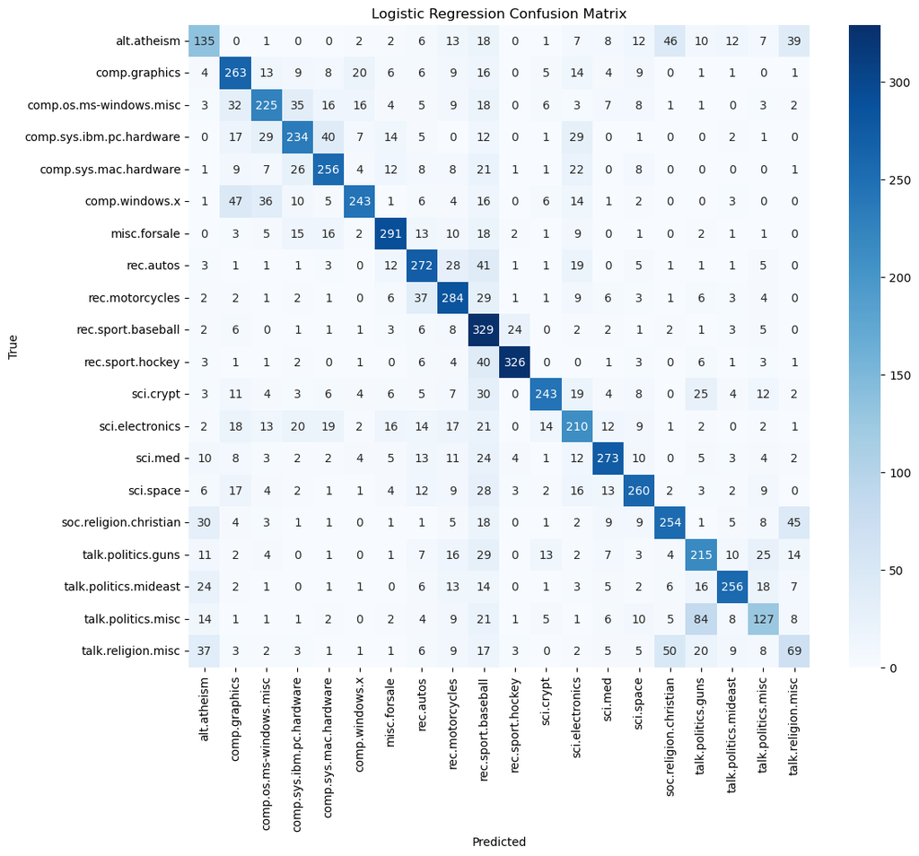

```
BOW Tuning & Training Linear SVM
Fitting 3 folds for each of 3 candidates, totalling 9 fits
```

```
              precision    recall  f1-score   support

           0       0.46      0.43      0.44       319
           1       0.58      0.67      0.62       389
           2       0.55      0.55      0.55       394
           3       0.52      0.57      0.55       392
           4       0.64      0.65      0.64       385
           5       0.73      0.62      0.67       395
           6       0.70      0.73      0.72       390
           7       0.63      0.64      0.64       396
           8       0.67      0.67      0.67       398
           9       0.51      0.80      0.62       397
          10       0.85      0.82      0.84       399
          11       0.74      0.67      0.70       396
          12       0.50      0.45      0.48       393
          13       0.74      0.67      0.70       396
          14       0.70      0.64      0.67       394
          15       0.59      0.63      0.61       398
          16       0.55      0.55      0.55       364
          17       0.75      0.68      0.71       376
          18       0.45      0.38      0.41       310
          19       0.32      0.27      0.29       251

    accuracy                           0.61      7532
   macro avg       0.61      0.60      0.60      7532
weighted avg       0.62      0.61      0.61      7532


Best Parameters: {'C': 0.1}
Test Accuracy: 0.6150
F1 Score (macro): 0.6044
```

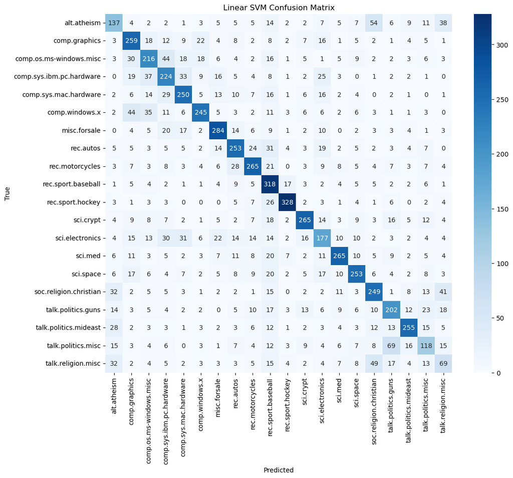

```
BOW Tuning & Training Random Forest
Fitting 3 folds for each of 4 candidates, totalling 12 fits
              precision    recall  f1-score   support

           0       0.44      0.36      0.40       319
           1       0.58      0.57      0.57       389
           2       0.54      0.58      0.56       394
           3       0.62      0.59      0.61       392
           4       0.59      0.63      0.61       385
           5       0.60      0.63      0.62       395
           6       0.64      0.73      0.68       390
           7       0.39      0.66      0.49       396
           8       0.66      0.66      0.66       398
           9       0.70      0.78      0.74       397
          10       0.78      0.79      0.78       399
          11       0.80      0.63      0.70       396
          12       0.52      0.44      0.48       393
          13       0.70      0.62      0.66       396
          14       0.69      0.64      0.67       394
          15       0.56      0.81      0.66       398
          16       0.51      0.55      0.53       364
          17       0.82      0.68      0.74       376
          18       0.49      0.33      0.39       310
          19       0.25      0.05      0.08       251

    accuracy                           0.60      7532
   macro avg       0.59      0.59      0.58      7532
weighted avg       0.60      0.60      0.60      7532


Best Parameters: {'max_depth': None, 'n_estimators': 200}
Test Accuracy: 0.6028
F1 Score (macro): 0.5818
```

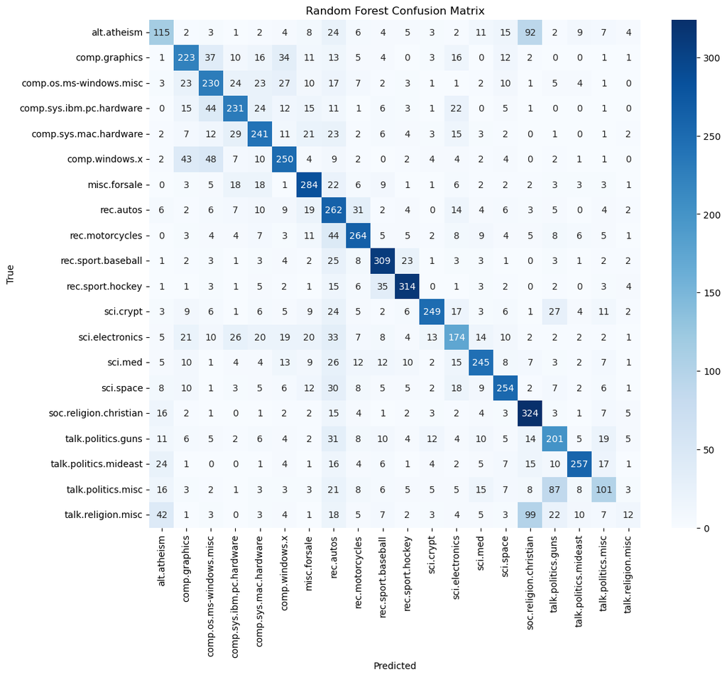

```
                     Model  Accuracy  F1-macro   TrainTime  EvalTime
0  BOW-Logistic Regression  0.632634  0.623939   11.959476  0.005599
1           BOW-Linear SVM  0.614976  0.604439  204.679376  0.005358
2        BOW-Random Forest  0.602762  0.581770   17.928221  0.116292
```

```python
results_bow = train_evaluate_classifiers(
    X_train_bow_vec, X_test_bow_vec, y_train, y_test, "BOW"
)
print(results_bow)
```

```
TF-IDF Tuning & Training Logistic Regression
Fitting 3 folds for each of 3 candidates, totalling 9 fits
              precision    recall  f1-score   support

           0       0.50      0.47      0.48       319
           1       0.61      0.69      0.65       389
           2       0.63      0.60      0.62       394
           3       0.62      0.63      0.62       392
           4       0.69      0.70      0.69       385
           5       0.81      0.66      0.73       395
           6       0.72      0.75      0.74       390
           7       0.47      0.76      0.58       396
           8       0.73      0.70      0.72       398
           9       0.83      0.78      0.81       397
          10       0.91      0.85      0.88       399
          11       0.80      0.69      0.74       396
          12       0.57      0.56      0.56       393
          13       0.79      0.76      0.78       396
          14       0.74      0.68      0.71       394
          15       0.64      0.73      0.68       398
          16       0.57      0.62      0.60       364
          17       0.80      0.72      0.76       376
          18       0.53      0.45      0.49       310
          19       0.35      0.29      0.32       251

    accuracy                           0.67      7532
   macro avg       0.67      0.65      0.66      7532
weighted avg       0.68      0.67      0.67      7532


Best Parameters: {'C': 10}
Test Accuracy: 0.6658
F1 Score (macro): 0.6568
```

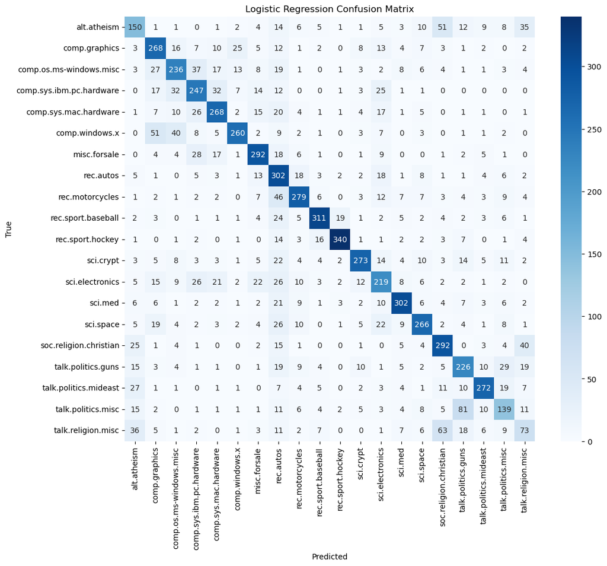

```
TF-IDF Tuning & Training Linear SVM
Fitting 3 folds for each of 3 candidates, totalling 9 fits
              precision    recall  f1-score   support

           0       0.53      0.46      0.49       319
           1       0.64      0.68      0.66       389
           2       0.62      0.63      0.62       394
           3       0.67      0.65      0.66       392
           4       0.72      0.71      0.71       385
           5       0.80      0.70      0.75       395
           6       0.70      0.76      0.73       390
           7       0.76      0.68      0.72       396
           8       0.79      0.74      0.76       398
           9       0.55      0.84      0.66       397
          10       0.86      0.90      0.88       399
          11       0.84      0.70      0.77       396
          12       0.58      0.55      0.56       393
          13       0.76      0.79      0.77       396
          14       0.74      0.73      0.73       394
          15       0.61      0.80      0.69       398
          16       0.58      0.69      0.63       364
          17       0.82      0.75      0.78       376
          18       0.55      0.45      0.50       310
          19       0.47      0.18      0.26       251

    accuracy                           0.68      7532
   macro avg       0.68      0.67      0.67      7532
weighted avg       0.69      0.68      0.68      7532


Best Parameters: {'C': 0.1}
Test Accuracy: 0.6831
F1 Score (macro): 0.6668
```

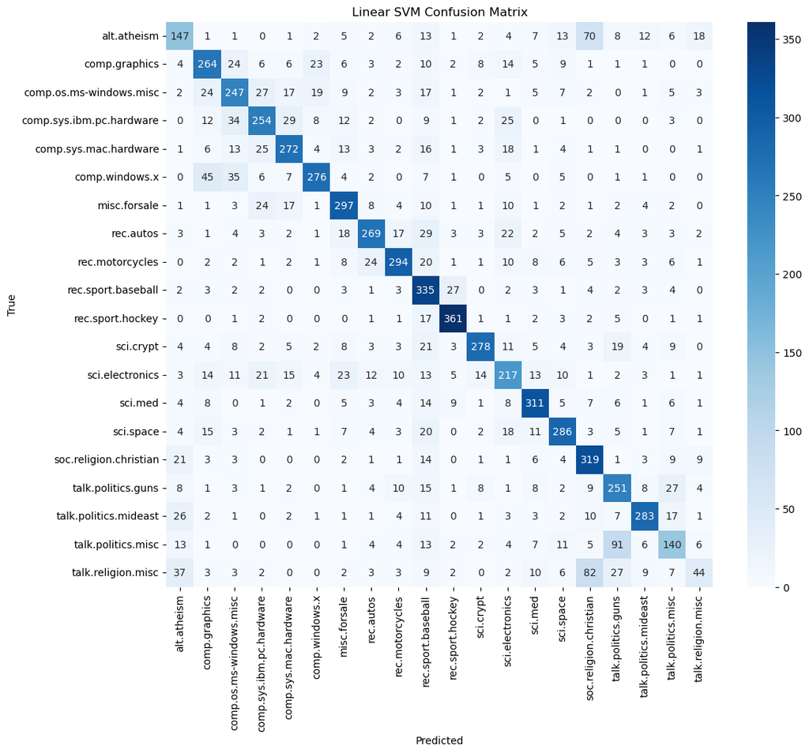

```
TF-IDF Tuning & Training Random Forest
Fitting 3 folds for each of 4 candidates, totalling 12 fits
              precision    recall  f1-score   support

           0       0.47      0.35      0.40       319
           1       0.57      0.57      0.57       389
           2       0.56      0.62      0.59       394
           3       0.62      0.58      0.60       392
           4       0.63      0.63      0.63       385
           5       0.63      0.62      0.63       395
           6       0.62      0.70      0.66       390
           7       0.41      0.67      0.51       396
           8       0.67      0.69      0.68       398
           9       0.75      0.77      0.76       397
          10       0.78      0.82      0.80       399
          11       0.81      0.64      0.72       396
          12       0.49      0.46      0.47       393
          13       0.65      0.67      0.66       396
          14       0.72      0.66      0.69       394
          15       0.56      0.81      0.66       398
          16       0.54      0.60      0.57       364
          17       0.83      0.70      0.76       376
          18       0.51      0.36      0.43       310
          19       0.26      0.06      0.10       251

    accuracy                           0.61      7532
   macro avg       0.61      0.60      0.59      7532
weighted avg       0.61      0.61      0.61      7532


Best Parameters: {'max_depth': None, 'n_estimators': 200}
Test Accuracy: 0.6146
F1 Score (macro): 0.5942
```

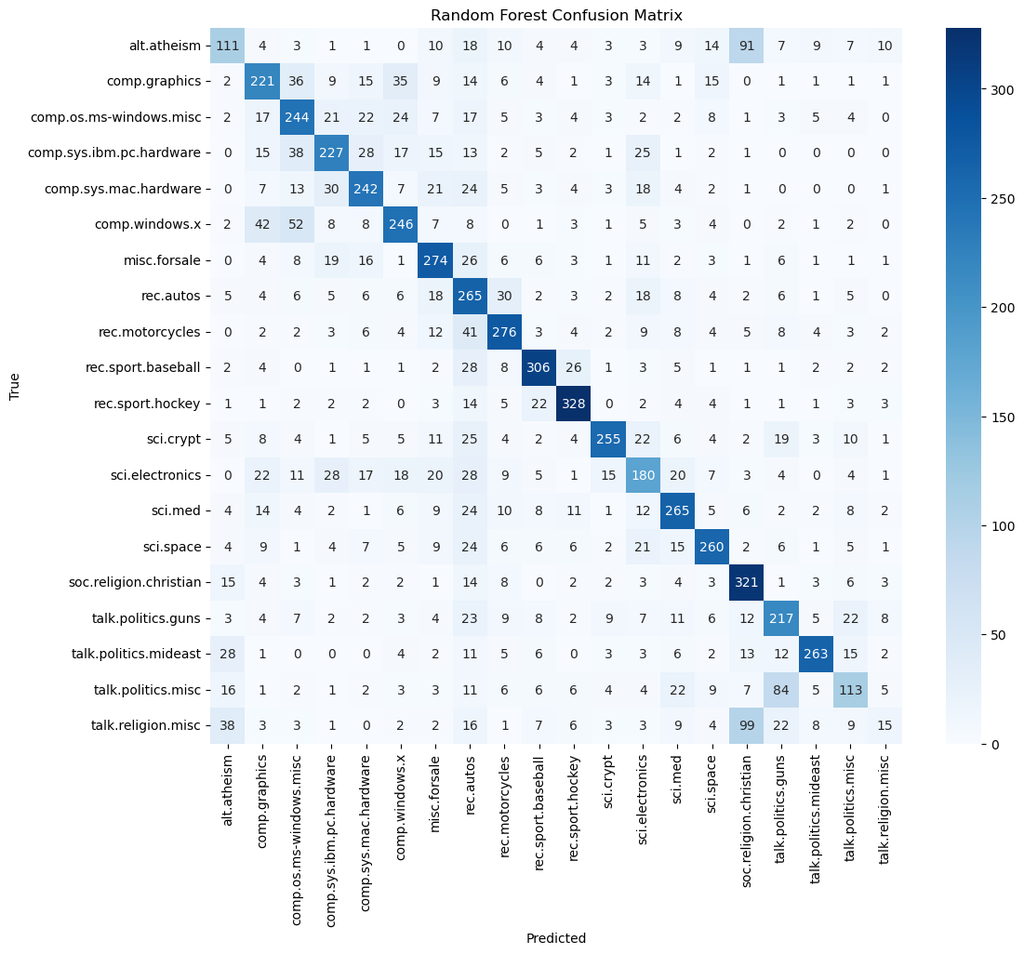

```python
results_tfidf = train_evaluate_classifiers(
    X_train_tfidf_vec, X_test_tfidf_vec, y_train, y_test, "TF-IDF"
)
```

```
Word2Vec Tuning & Training Logistic Regression
Fitting 3 folds for each of 3 candidates, totalling 9 fits
              precision    recall  f1-score   support

           0       0.46      0.43      0.44       319
           1       0.58      0.59      0.59       389
           2       0.54      0.53      0.54       394
           3       0.50      0.46      0.48       392
           4       0.51      0.51      0.51       385
           5       0.65      0.64      0.65       395
           6       0.77      0.71      0.74       390
           7       0.46      0.69      0.55       396
           8       0.69      0.63      0.66       398
           9       0.79      0.76      0.77       397
          10       0.82      0.83      0.82       399
          11       0.67      0.63      0.65       396
          12       0.54      0.49      0.51       393
          13       0.79      0.80      0.79       396
          14       0.72      0.71      0.71       394
          15       0.61      0.78      0.69       398
          16       0.52      0.64      0.58       364
          17       0.76      0.73      0.75       376
          18       0.45      0.38      0.41       310
          19       0.35      0.16      0.22       251

    accuracy                           0.62      7532
   macro avg       0.61      0.61      0.60      7532
weighted avg       0.62      0.62      0.61      7532


Best Parameters: {'C': 10}
Test Accuracy: 0.6180
F1 Score (macro): 0.6031
```

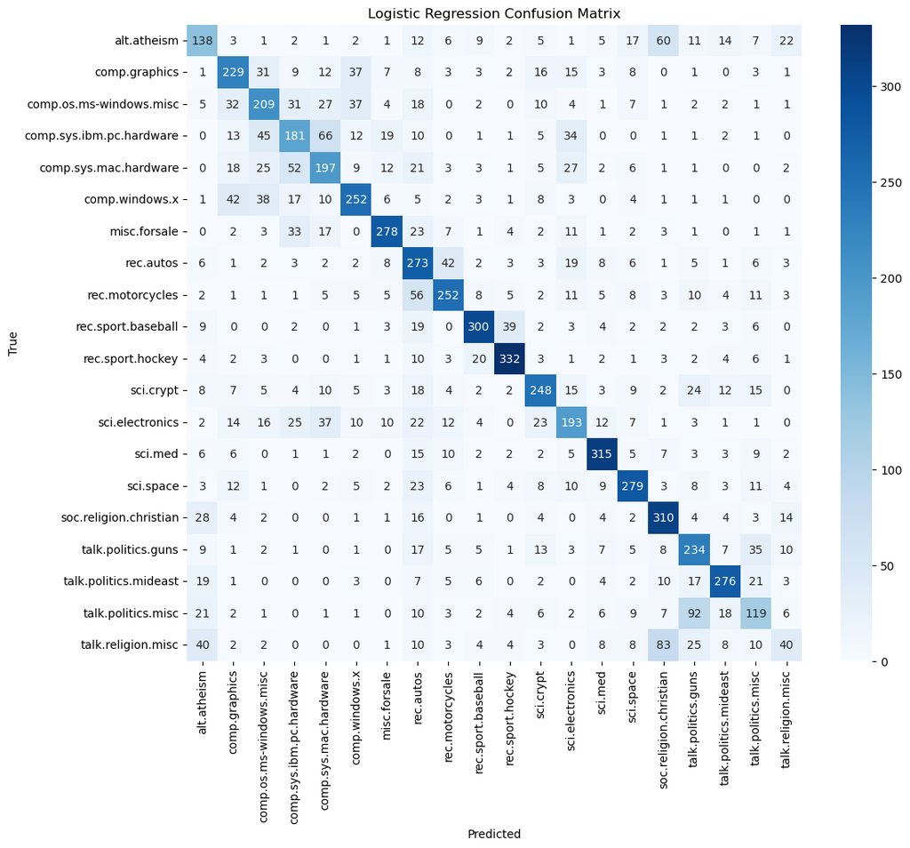

```
Word2Vec Tuning & Training Linear SVM
Fitting 3 folds for each of 3 candidates, totalling 9 fits
              precision    recall  f1-score   support

           0       0.46      0.36      0.41       319
           1       0.59      0.58      0.58       389
           2       0.55      0.51      0.53       394
           3       0.52      0.48      0.50       392
           4       0.56      0.47      0.51       385
           5       0.62      0.66      0.64       395
           6       0.73      0.74      0.73       390
           7       0.47      0.70      0.56       396
           8       0.71      0.65      0.68       398
           9       0.81      0.76      0.78       397
          10       0.78      0.84      0.81       399
          11       0.67      0.66      0.66       396
          12       0.54      0.51      0.53       393
          13       0.77      0.82      0.79       396
          14       0.68      0.70      0.69       394
          15       0.58      0.83      0.68       398
          16       0.51      0.63      0.56       364
          17       0.73      0.77      0.75       376
          18       0.49      0.37      0.42       310
          19       0.38      0.06      0.10       251

    accuracy                           0.62      7532
   macro avg       0.61      0.60      0.60      7532
weighted avg       0.61      0.62      0.61      7532


Best Parameters: {'C': 1}
Test Accuracy: 0.6202
F1 Score (macro): 0.5960
```

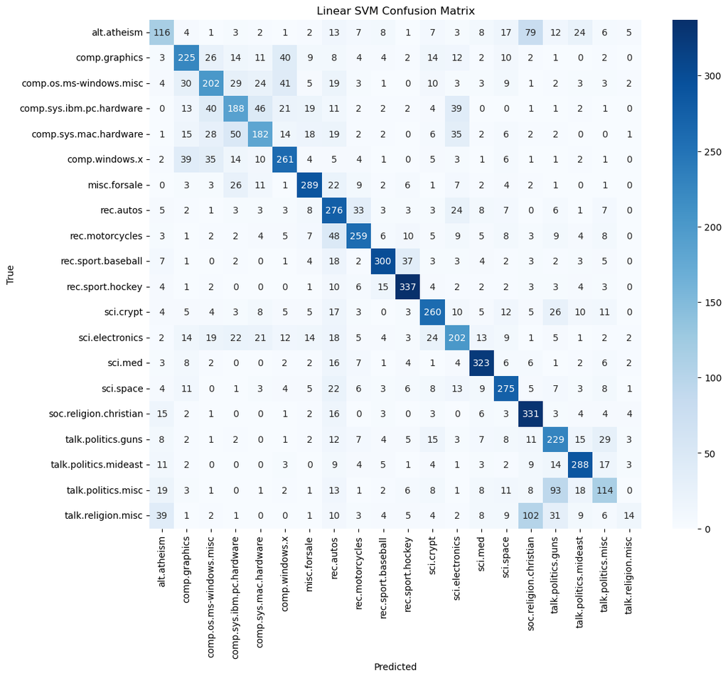

```
Word2Vec Tuning & Training Random Forest
Fitting 3 folds for each of 4 candidates, totalling 12 fits
              precision    recall  f1-score   support

           0       0.33      0.34      0.34       319
           1       0.51      0.53      0.52       389
           2       0.43      0.43      0.43       394
           3       0.43      0.49      0.46       392
           4       0.34      0.23      0.27       385
           5       0.53      0.53      0.53       395
           6       0.60      0.67      0.64       390
           7       0.39      0.57      0.46       396
           8       0.50      0.57      0.53       398
           9       0.66      0.66      0.66       397
          10       0.67      0.79      0.72       399
          11       0.59      0.50      0.54       396
          12       0.50      0.40      0.45       393
          13       0.71      0.74      0.72       396
          14       0.66      0.57      0.62       394
          15       0.53      0.79      0.63       398
          16       0.47      0.52      0.49       364
          17       0.72      0.65      0.68       376
          18       0.42      0.25      0.31       310
          19       0.27      0.05      0.09       251

    accuracy                           0.53      7532
   macro avg       0.51      0.51      0.51      7532
weighted avg       0.52      0.53      0.52      7532


Best Parameters: {'max_depth': None, 'n_estimators': 200}
Test Accuracy: 0.5281
F1 Score (macro): 0.5051
```

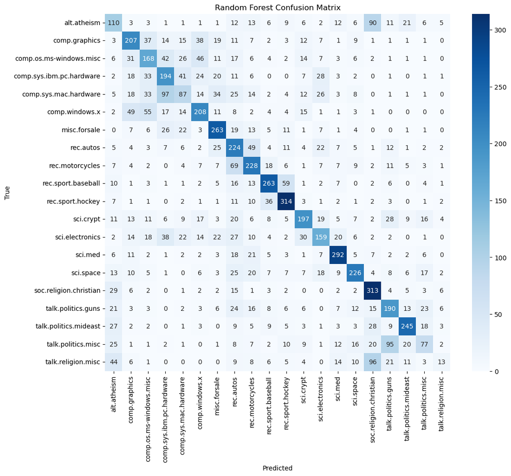

```python
results_w2v = train_evaluate_classifiers(
    X_train_w2v_vec, X_test_w2v_vec, y_train, y_test, "Word2Vec"
)
```

```python
# Use DistilBERT (lightweight and efficient for text classification)
bert_model_name = "distilbert-base-uncased"
tokenizer = AutoTokenizer.from_pretrained(bert_model_name)
# Initialize model for 20-category classification
model = AutoModelForSequenceClassification.from_pretrained(
    bert_model_name, num_labels=len(target_names)
)
model.to(device)


# Custom Dataset for 20 Newsgroups
class NewsGroupsDataset(Dataset):
    def __init__(self, texts, labels, tokenizer, max_len=512):
        self.texts = texts
        self.labels = labels
        self.tokenizer = tokenizer
        self.max_len = max_len

    def __len__(self):
        return len(self.texts)

    def __getitem__(self, idx):
        text = str(self.texts[idx])
        label = self.labels[idx]
        # Tokenize input text
        encoding = self.tokenizer(
            text,
            truncation=True,
            padding="max_length",
            max_length=self.max_len,
            return_tensors="pt",
        )
        # Remove extra batch dimension
        item = {key: val.squeeze(0) for key, val in encoding.items()}
        item["labels"] = torch.tensor(label, dtype=torch.long)
        return item


# Create datasets and dataloaders
train_dataset = NewsGroupsDataset(X_train, y_train, tokenizer, max_len=512)
test_dataset = NewsGroupsDataset(X_test, y_test, tokenizer, max_len=512)

train_loader = DataLoader(train_dataset, batch_size=16, shuffle=True)
test_loader = DataLoader(test_dataset, batch_size=16)
```

[output not shown]

```
Average Loss: 1.8511
```

```
Average Loss: 0.8698
```

```
Average Loss: 0.6176
```

```
Average Loss: 0.4870
```

```
              precision    recall  f1-score   support

           0       0.49      0.50      0.49       319
           1       0.69      0.70      0.70       389
           2       0.68      0.66      0.67       394
           3       0.64      0.65      0.65       392
           4       0.72      0.70      0.71       385
           5       0.86      0.77      0.81       395
           6       0.84      0.81      0.82       390
           7       0.53      0.77      0.63       396
           8       0.74      0.73      0.74       398
           9       0.87      0.82      0.85       397
          10       0.91      0.90      0.90       399
          11       0.75      0.72      0.73       396
          12       0.63      0.62      0.63       393
          13       0.83      0.85      0.84       396
          14       0.78      0.78      0.78       394
          15       0.67      0.80      0.73       398
          16       0.57      0.66      0.61       364
          17       0.84      0.78      0.81       376
          18       0.52      0.46      0.49       310
          19       0.30      0.12      0.17       251

    accuracy                           0.71      7532
   macro avg       0.69      0.69      0.69      7532
weighted avg       0.70      0.71      0.70      7532

Bert Test Accuracy: 0.7054
Bert F1 Score (macro): 0.6874
```

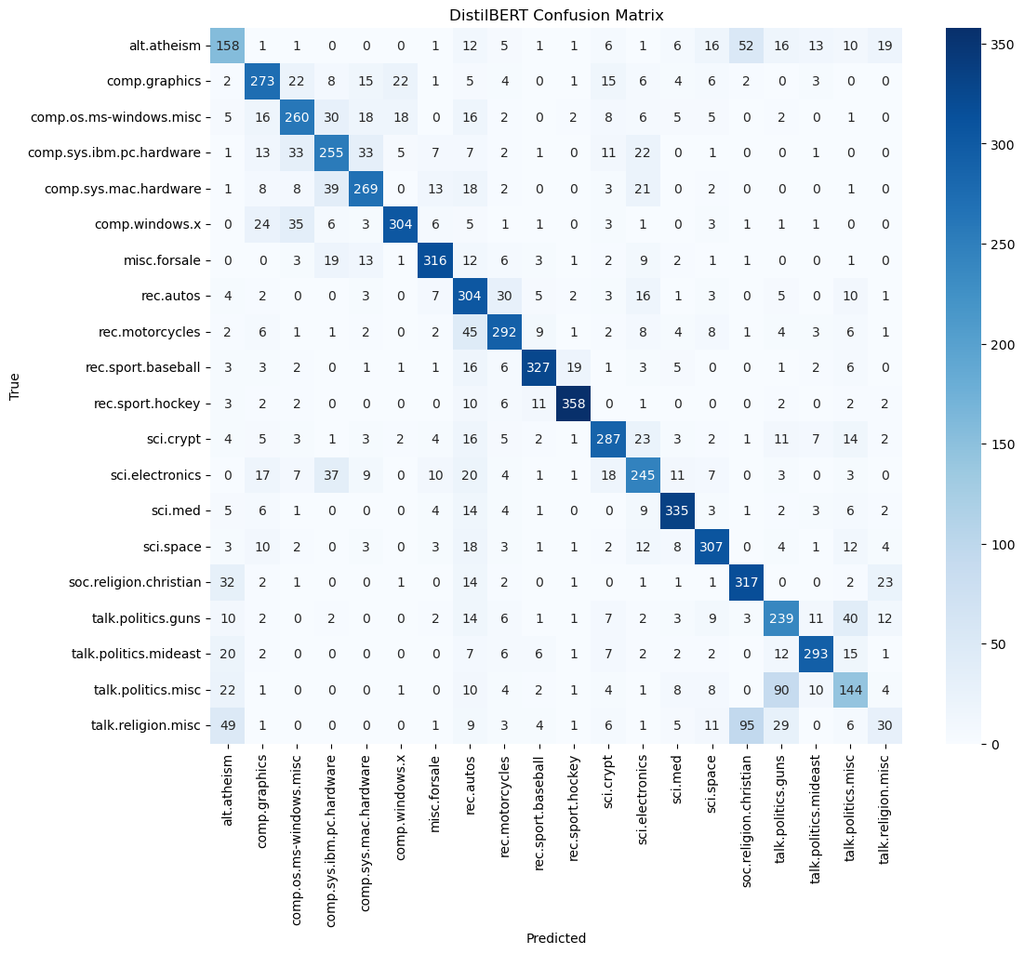

```python
# Training hyperparameters
epochs = 4
optimizer = torch.optim.AdamW(model.parameters(), lr=2e-5, weight_decay=0.01)
# Total training steps and warmup steps for scheduler
total_steps = len(train_loader) * epochs
warmup_steps = int(total_steps * 0.1)
scheduler = get_linear_schedule_with_warmup(
    optimizer, num_warmup_steps=warmup_steps, num_training_steps=total_steps
)
# Automatic mixed precision for faster training
scaler = torch.amp.GradScaler(device=device)
start_train = time.time()
model.train()
for epoch in range(epochs):
    total_loss = 0
    for batch in tqdm(train_loader, desc="Training..."):
        # Move data to the same device as the model
        input_ids = batch["input_ids"].to(device)
        attention_mask = batch["attention_mask"].to(device)
        labels = batch["labels"].to(device)
        optimizer.zero_grad()
        # Forward pass with mixed precision
        with torch.amp.autocast(device_type=device.type):
            outputs = model(input_ids, attention_mask=attention_mask, labels=labels)
            loss = outputs.loss
        # Backward pass and optimization
        scaler.scale(loss).backward()
        scaler.unscale_(optimizer)
        # Gradient clipping to prevent exploding gradients
        torch.nn.utils.clip_grad_norm_(model.parameters(), 1.0)
        scaler.step(optimizer)
        scaler.update()
        scheduler.step()
        total_loss += loss.item()
    avg_loss = total_loss / len(train_loader)
    print(f"Average Loss: {avg_loss:.4f}")
end_train = time.time()
train_time = end_train - start_train

# Evaluation
start_eval_time = time.time()
model.eval()
y_pred_bert = []
with torch.no_grad():
    for batch in tqdm(test_loader, desc="Evaluation..."):
        input_ids = batch["input_ids"].to(device)
        attention_mask = batch["attention_mask"].to(device)
        outputs = model(input_ids, attention_mask=attention_mask)
        preds = torch.argmax(outputs.logits, dim=1).cpu().numpy()
        y_pred_bert.extend(preds)
end_eval_time = time.time()

acc_bert = accuracy_score(y_test, y_pred_bert)
f1_bert = f1_score(y_test, y_pred_bert, average="macro")
cm_bert = confusion_matrix(y_test, y_pred_bert)

print(classification_report(y_test, y_pred_bert))
print(f"Bert Test Accuracy: {acc_bert:.4f}")
print(f"Bert F1 Score (macro): {f1_bert:.4f}\n")

# Plot confusion matrix
plt.figure(figsize=(12, 10))
sns.heatmap(
    cm_bert,
    annot=True,
    fmt="d",
    cmap="Blues",
    xticklabels=target_names,
    yticklabels=target_names,
)
plt.title("DistilBERT Confusion Matrix")
plt.ylabel("True")
plt.xlabel("Predicted")
plt.show()

results_bert = pd.DataFrame(
    [
        {
            "Model": "BERT",
            "Accuracy": acc_bert,
            "F1-macro": f1_bert,
            "TrainTime": train_time,
            "EvalTime": end_eval_time - start_eval_time,
        }
    ]
)
```

```python
df_all = pd.concat(
    [results_bow, results_tfidf, results_w2v, results_bert], ignore_index=True
)
print("All Models Performance Summary")
print(df_all.round(4))
```

```
All Models Performance Summary
                          Model  Accuracy  F1-macro  TrainTime  EvalTime
0       BOW-Logistic Regression    0.6326    0.6239    11.9595    0.0056
1                BOW-Linear SVM    0.6150    0.6044   204.6794    0.0054
2             BOW-Random Forest    0.6028    0.5818    17.9282    0.1163
3    TF-IDF-Logistic Regression    0.6658    0.6568     9.0172    0.0070
4             TF-IDF-Linear SVM    0.6831    0.6668     2.3850    0.0059
5          TF-IDF-Random Forest    0.6146    0.5942    20.2005    0.1302
6  Word2Vec-Logistic Regression    0.6180    0.6031     3.2096    0.0062
7           Word2Vec-Linear SVM    0.6202    0.5960    27.5410    0.0039
8        Word2Vec-Random Forest    0.5281    0.5051    25.5340    0.0983
9                          BERT    0.7054    0.6874   667.9603   95.3053
```

```python
best_acc = df_all.loc[df_all["Accuracy"].idxmax()]
best_f1 = df_all.loc[df_all["F1-macro"].idxmax()]

print("Best Model by Accuracy:")
print(f" - {best_acc['Model']} | Accuracy: {best_acc['Accuracy']:.4f}")
print()
print("Best Model by F1-macro:")
print(f" - {best_f1['Model']} | F1: {best_f1['F1-macro']:.4f}")
```

```
Best Model by Accuracy:
 - BERT | Accuracy: 0.7054

Best Model by F1-macro:
 - BERT | F1: 0.6874
```

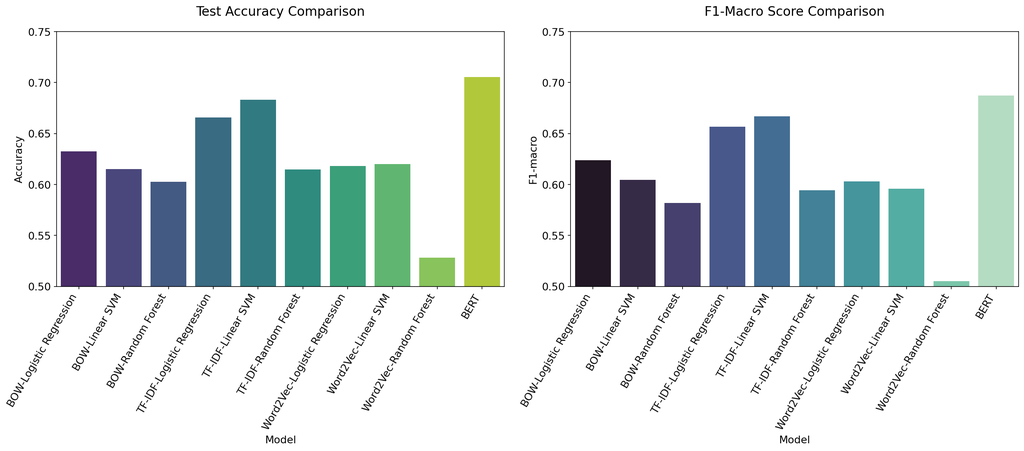

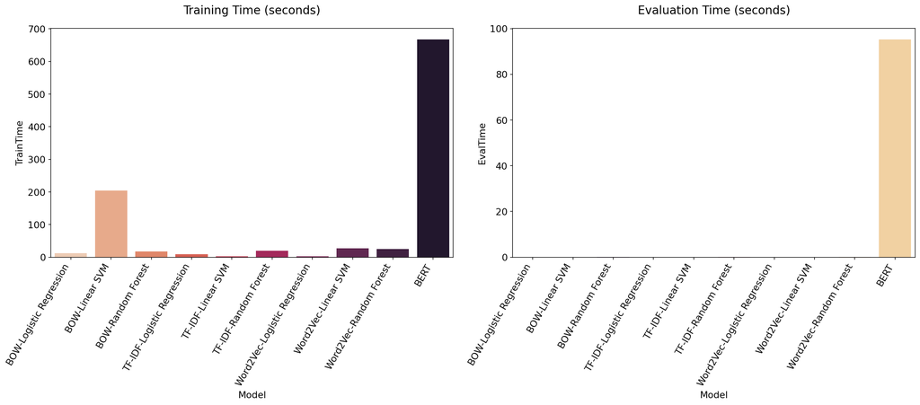

```python
plt.rcParams["figure.dpi"] = 150
plt.rcParams["font.size"] = 13
plt.figure(figsize=(18, 8))

plt.subplot(1, 2, 1)
sns.barplot(
    x="Model", y="Accuracy", data=df_all, hue="Model", palette="viridis", legend=False
)
plt.title("Test Accuracy Comparison", fontsize=16, pad=20)
plt.ylim(0.5, 0.75)
plt.xticks(rotation=60, ha="right")

plt.subplot(1, 2, 2)
sns.barplot(
    x="Model", y="F1-macro", data=df_all, hue="Model", palette="mako", legend=False
)
plt.title("F1-Macro Score Comparison", fontsize=16, pad=20)
plt.ylim(0.5, 0.75)
plt.xticks(rotation=60, ha="right")

plt.tight_layout()
plt.show()

plt.figure(figsize=(18, 8))

plt.subplot(1, 2, 1)
sns.barplot(
    x="Model", y="TrainTime", data=df_all, hue="Model", palette="rocket_r", legend=False
)
plt.title("Training Time (seconds)", fontsize=16, pad=20)
plt.xticks(rotation=60, ha="right")

plt.subplot(1, 2, 2)
sns.barplot(
    x="Model", y="EvalTime", data=df_all, hue="Model", palette="magma", legend=False
)
plt.title("Evaluation Time (seconds)", fontsize=16, pad=20)
plt.xticks(rotation=60, ha="right")

plt.tight_layout()
plt.show()
```

```python
# Extract misclassified examples from test set
mis_idx = []
y_test_np = np.array(y_test)
y_pred_np = np.array(y_pred_bert)

for i in range(len(y_test_np)):
    if y_test_np[i] != y_pred_np[i]:
        mis_idx.append((i, y_test_np[i], y_pred_np[i]))

# Show 5 real misclassified examples
print("=== MISCLASSIFIED EXAMPLES ===")
for i, (idx, true, pred) in enumerate(mis_idx[:5]):
    print(f"\nExample {i+1}")
    print(f"True Label: {target_names[true]}")
    print(f"Wrong Pred: {target_names[pred]}")
    print(f"Text:{X_test[idx][:300]}...\n")  # first 300 chars
```

```
=== MISCLASSIFIED EXAMPLES ===

Example 1
True Label: alt.atheism
Wrong Pred: talk.politics.mideast
Text:
In a word, yes.
...


Example 2
True Label: talk.religion.misc
Wrong Pred: alt.atheism
Text:
I've just spent two solid months arguing that no such thing as an
objective moral system exists....


Example 3
True Label: soc.religion.christian
Wrong Pred: alt.atheism
Text:Dishonest money dwindles away, but he who gathers money little by little makes
it grow.
Proverbs 13:11
...


Example 4
True Label: soc.religion.christian
Wrong Pred: comp.os.ms-windows.misc
Text:A friend of mine managed to get a copy of a computerised Greek and Hebrew
Lexicon called "The Word Perfect" (That is not the word processing
package WordPerfect). However, some one wiped out the EXE file, and she
has not been able to restore it. There are no distributors of the package in
South ...


Example 5
True Label: rec.motorcycles
Wrong Pred: alt.atheism
Text:
Accusation?  I thought it was a recommendation.  (I mean, I did grow up there,
I oughta know).


Bring the truck and about 10 pounds of crawfish and we'll talk.


...
```

## Example 1

- **Reason**: The text is extremely short with almost no domain-specific keywords. It contains only a vague general statement without any words related to atheism or Middle East politics. Due to semantic ambiguity and insufficient contextual information, the model cannot capture effective topic features and makes a random misclassification.

## Example 2

- **Reason**: The content focuses on discussions about moral system, objective existence and philosophical debate, which are highly overlapping core topics between religion and atheism. The shared abstract philosophical vocabulary and similar argumentative writing style cause semantic ambiguity, leading the model to confuse the two religious-related categories.

## Example 3

- **Reason**: Although the text is quoted from the Bible and belongs to Christian culture, it only contains a common life maxim without obvious religious proper nouns. Atheism also frequently discusses moral and life values in daily debates. The lack of unique religious markers results in misclassification due to lexical and thematic similarity.

## Example 4

- **Reason**: The original text involves religious lexicon resources, but it is dominated by a large number of computer technical terms such as computerised, EXE file, restore, package. The computer-related vocabulary occupies the main feature weight, overwhelming the implicit religious background information. The model is misled by dominant technical words and misclassified into a computer system category.

## Example 5

- **Reason**: The text is daily colloquial dialogue with no motorcycle-related professional keywords at all. It only contains casual daily communication and life arrangements, without obvious domain features. The vague and general expression makes the model fail to identify the motorcycle topic and wrongly assign it to the ambiguous atheism discussion category.

# Category Confusion Analysis Based on Confusion Matrix

According to the precision, recall and F1-score of all models (BOW, TF-IDF, Word2Vec, BERT) on the 20 Newsgroups dataset, combined with the inherent topic characteristics of each category, the most easily confused category pairs and their confusion patterns are summarized as follows. Categories with obviously low precision, recall and F1-score are regarded as highly confusing groups, and the confusion trend is consistent across all models.

## 1. Most Confused Category Pairs

- **Confusion reason**: Both contain controversial discussions and share similar sentence patterns and opinion expressions. Overlapping general words such as *discussion, opinion, debate* make it difficult for traditional methods (BOW, TF-IDF, Word2Vec) to capture semantic differences.

### 1.2 talk.religion.misc (Category 19)

- **Confusion reason**: It has the **smallest sample size** (only 251 samples), leading to insufficient model training. Its topic boundary is vague and highly overlaps with other daily discussion categories.

### 1.3 Computer Subcategories (comp.graphics, comp.os.ms-windows.misc, comp.windows.x)

These closely related computer subcategories show similar moderate precision and recall values and are easily misclassified into each other.

- **Confusion reason**: They belong to the same major computer domain and share a large number of professional technical vocabularies such as *system, program, window, graphic*. Traditional word-based methods cannot distinguish fine-grained topic differences.

### 1.4 Sports Subcategories (rec.sport.baseball & rec.sport.hockey)

- **Confusion reason**: They share identical sports-related vocabulary such as *team, player, match, game*, and have highly similar discourse scenarios, making fine-grained differentiation difficult.

### 1.5 Science & Technology Categories (sci.space, sci.electronics, sci.med)

Scientific categories are easily mixed with each other due to academic writing styles and overlapping technical terminology.

- **Confusion reason**: Formal sentence structures and shared research-related words weaken the feature distinction among different scientific fields.

## 3. Summary

Category confusion mainly occurs among semantically similar subcategories within the same domain and categories with insufficient training samples. Traditional text representation methods suffer from weak semantic discrimination, while the pre-trained BERT model effectively improves classification performance and reduces confusion by modeling contextual semantics.